# Predicting ICU Portality in Adults Using MIMIC-IV Data

BMIN503/EPID600 Final Project

Author

Madison Carrigan

## 1 Overview

This project investigates the factors influencing mortality in adult ICU patients using the MIMIC-IV dataset. By analyzing clinical and demographic data, the project compares traditional logistic regression models with advanced machine learning techniques such as Random Forest and XGBoost. The ultimate goal is to identify key predictors of ICU mortality, assess the potential of AI-driven models to enhance prediction accuracy, and explore how these models could support clinicians in making data-informed decisions to improve patient care.

## 2 Introduction

Understanding the predictors of ICU mortality is critical for improving patient outcomes and optimizing resource allocation in intensive care units. ICU mortality rates vary significantly depending on patient demographics, comorbidities, and clinical interventions. Accurate mortality predictions can help guide decisions about patient care, prioritize interventions, and allocate resources effectively.

Traditional logistic regression provides a robust and interpretable framework but is often constrained by its linear assumptions. Machine learning techniques, such as Random Forest and XGBoost, overcome these limitations by capturing non-linear relationships and complex interactions among variables, enabling more accurate and nuanced predictions.

This study integrates data science, clinical medicine, and biomedical informatics to address ICU mortality prediction. Data science contributes advanced machine learning methods, clinical expertise informs the selection of meaningful predictors, and biomedical informatics supports the integration and analysis of complex datasets. Conversations with experts in ophthalmology and biomedical informatics highlighted the importance of accurate mortality prediction in managing ICU outcomes. By leveraging insights from these fields, this project evaluates AI’s potential to improve the accuracy and utility of ICU mortality prediction models, offering data-driven insights to enhance clinical decision-making.

## 3 Methods

### 3.1 To begin the project, the first step involves data retrieval and preprocessing on the MIMIC-IV dataset.

### 3.2 Install Required Libraries:

```r
options(repos = c(CRAN = "https://cran.rstudio.com/"))

suppressMessages(suppressWarnings(install.packages(c("DBI", "dbplyr", "RPostgres", "tidyverse", "lubridate", "ggplot2", "caret", "randomForest", "xgboost", "pROC", "skimr", "corrplot", "RSQLite", "tidyverse", "data.table", "Matrix", "caTools"))))
# Load all packages
suppressPackageStartupMessages({
  library(DBI)
  library(dbplyr)
  library(RPostgres)
  library(tidyverse)
  library(lubridate)
  library(ggplot2)
  library(caret)
  library(randomForest)
  library(xgboost)
  library(pROC)
  library(skimr)
  library(corrplot)
  library(RSQLite)
  library(tidyverse)
  library(data.table)
  library(reshape2)
  library(Matrix)
  library(caTools)
})

# Print a message to confirm successful setup
cat("All packages successfully installed and loaded!\n")
```

```
All packages successfully installed and loaded!
```

## 4 **Data Extraction**

### 4.1 Data was extracted from the MIMIC-IV dataset, focusing on ICU stays, demographics, and mortality outcomes.

```r
hosp_path <- "~/Desktop/mimic-iv-3.1/mimic-iv-3.1/hosp"
icu_path <- "~/Desktop/mimic-iv-3.1/mimic-iv-3.1/icu"

hosp_files <- list.files(path = hosp_path, pattern = "*.csv", full.names = TRUE)
hosp_data <- lapply(hosp_files, function(file) read_csv(file, show_col_types = FALSE))
names(hosp_data) <- basename(hosp_files) %>% str_remove(".csv")

icu_files <- list.files(path = icu_path, pattern = "*.csv", full.names = TRUE)
icu_data <- lapply(icu_files, function(file) read_csv(file, show_col_types = FALSE))
names(icu_data) <- basename(icu_files) %>% str_remove(".csv")
```

### 4.2 **Data Cleaning -** clean and prepare data - handle missing values and transform variables

```r
icustays_data <- icu_data[["icustays"]]
patients_data <- hosp_data[["patients"]]
admissions_data <- hosp_data[["admissions"]]  # Replace "admissions" with the correct name

# Query ICU admissions with patient demographics and outcomes
icu_data <- icustays_data %>%
  inner_join(patients_data, by = c("subject_id" = "subject_id")) %>%
  inner_join(admissions_data, by = c("hadm_id" = "hadm_id")) %>%
  select(subject_id.x, hadm_id, stay_id, gender, dod, intime, outtime, anchor_age, deathtime) %>%
  filter(anchor_age >= 18) %>% # Focus on adults
  collect() # Pull the data into R for local analysis

# Save extracted data for reuse
dir.create("data", showWarnings = FALSE) # Create the directory if it doesn't exist
write_csv(icu_data, "data/icu_data.csv")
```

```r
# Load ICU data
icu_data <- read_csv("data/icu_data.csv")
# Clean data
icu_data <- icu_data %>%
  mutate(length_of_stay = as.numeric(difftime(outtime, intime, units = "days")),
         death = ifelse(deathtime == "Y", 1, 0)) %>%
  filter(length_of_stay > 0) # Remove invalid stays

# Summary statistics to check - uncomment the code line below if you would like to see
#summary(icu_data)
```

### 4.3 Exploratory Data Analysis - Visualizing trends and relationships in the data

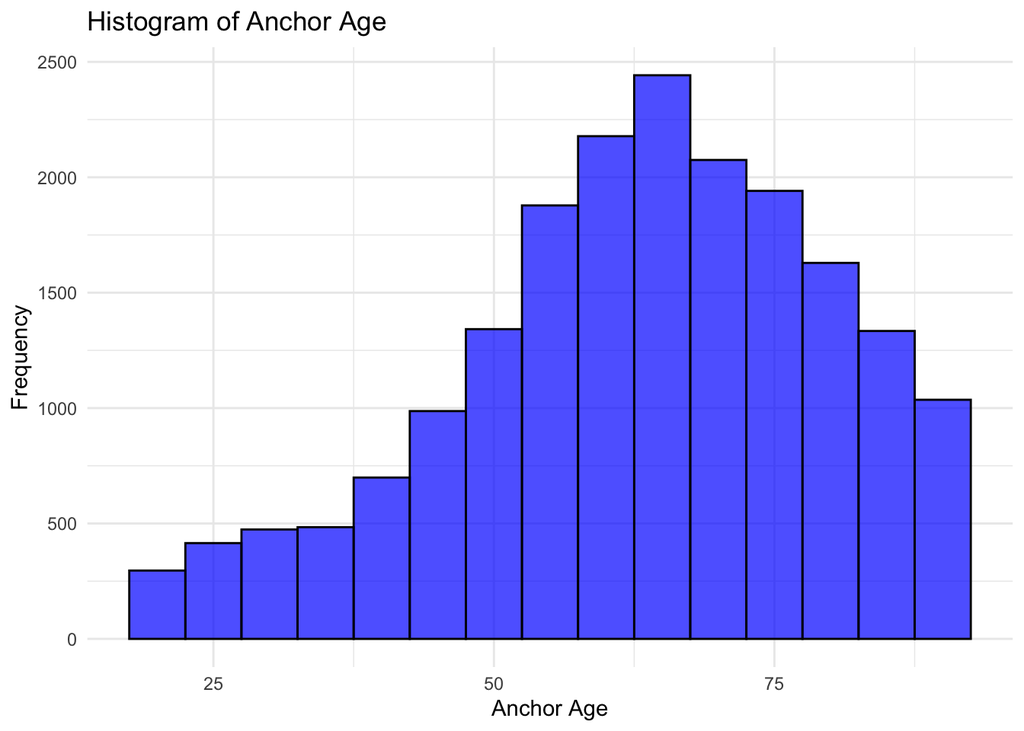

```r
# Histogram of 'anchor_age'
ggplot(icu_data, aes(x = anchor_age)) +
  geom_histogram(binwidth = 5, fill = "blue", color = "black", alpha = 0.7) +
  labs(title = "Histogram of Anchor Age", x = "Anchor Age", y = "Frequency") +
  theme_minimal()
```

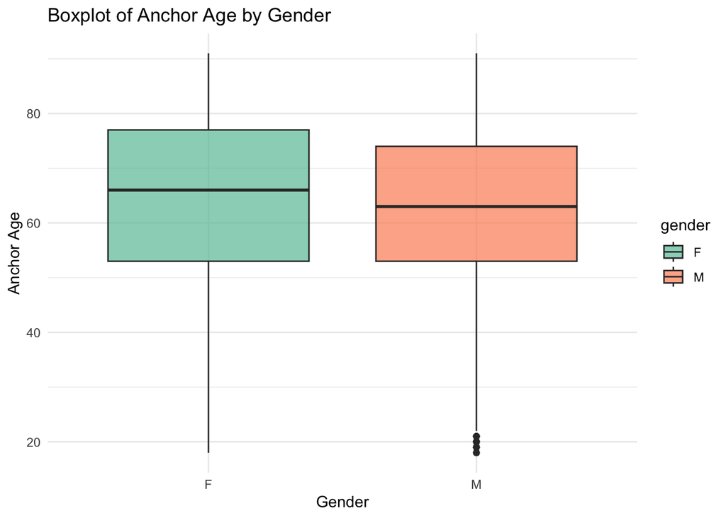

```r
# Boxplot of 'anchor_age' by 'gender'
ggplot(icu_data, aes(x = gender, y = anchor_age, fill = gender)) +
  geom_boxplot(alpha = 0.7) +
  labs(title = "Boxplot of Anchor Age by Gender", x = "Gender", y = "Anchor Age") +
  theme_minimal() +
  scale_fill_brewer(palette = "Set2")
```

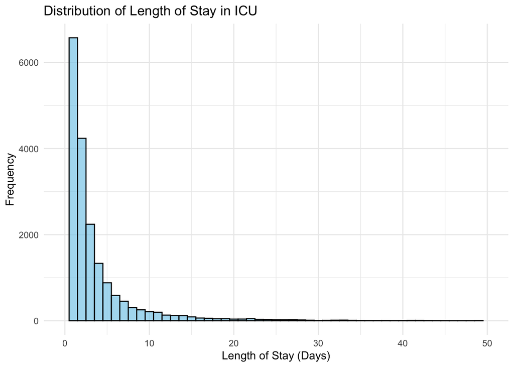

```r
# Histogram of Length of Stay with x-axis range from 0 to 50
ggplot(icu_data, aes(x = length_of_stay)) +
  geom_histogram(binwidth = 1, fill = "skyblue", color = "black", alpha = 0.7) +
  labs(title = "Distribution of Length of Stay in ICU",
       x = "Length of Stay (Days)",
       y = "Frequency") +
  theme_minimal() +
  scale_x_continuous(limits = c(0, 50))  # Set x-axis scale from 0 to 50
```